# Xenium Cell-Cell Communication Book

Cell geometry, spatial neighbors, and proximity networks

Author

Affiliation

[Flávio Gabriel Carazza-Kessler](https://github.com/flaviogckessler)

Federal University of Paraná (UFPR)

Published

November 11, 2026

This book follows five Xenium analysis vignettes in the requested order. It starts with cell segmentation polygons, measures their geometry, compares Delaunay and polygon proximity graphs, explores the distance threshold, and finishes with close-up views of direct neighbors and representative points in their contact regions. Each numbered chapter corresponds to one vignette.

The chapters share one R session. Packages, data, spatial metrics, and neighbor candidates are prepared once and reused. Spatial figures show the explicit `ggplot()` calls and RGraphSpace geoms used in the scripts and vignettes. The HTML contains its figures and animation, so it can be read offline.

# Before you begin

## About the author

**Flávio Gabriel Carazza-Kessler** is a PhD candidate in Bioinformatics at the Federal University of Paraná (UFPR).

[GitHub](https://github.com/flaviogckessler) · [LinkedIn](https://www.linkedin.com/in/flaviogckessler/) · [Lattes](http://lattes.cnpq.br/0370990742893359) · [Google Scholar](https://scholar.google.com.br/citations?user=DYrSfHYAAAAJ&hl=pt-BR&oi=ao)

## Paths and execution

Keep this source file in the project’s `Book` folder. The original dataset is read from `../data`; new figures, animation frames, and result tables are saved inside `Book`. All R chunks are evaluated and their code is displayed. An R error stops the render.

```r
book_dir <- normalizePath(
  dirname(knitr::current_input(dir = TRUE)),
  winslash = "/", mustWork = TRUE
)
project_root <- normalizePath(
  file.path(book_dir, ".."), winslash = "/", mustWork = TRUE
)
figure_dir <- file.path(book_dir, "figures")
frame_dir <- file.path(book_dir, "frames")
result_dir <- file.path(book_dir, "results")
for (directory in c(figure_dir, frame_dir, result_dir)) {
  dir.create(directory, recursive = TRUE, showWarnings = FALSE)
}
knitr::opts_chunk$set(eval = TRUE, echo = TRUE)
knitr::opts_knit$set(root.dir = book_dir)
options(repos = c(CRAN = "https://cloud.r-project.org"))
options(timeout = max(600, getOption("timeout")))
set.seed(42)
```

## Check and load packages

Check each dependency before installing it. Missing packages are installed into a project-local library. Existing installations are reused. `microbiome` comes from Bioconductor; `RGraphSpace` is installed from its development repository if the required version is unavailable. Seurat, gridExtra, and ggpubr are unnecessary here because the book uses the GraphSpace object directly and combines plots with patchwork.

```r
local_library <- file.path(book_dir, "_R_library")
if (dir.exists(local_library)) {
  .libPaths(c(local_library, .libPaths()))
}
prepare_local_library <- function() {
  dir.create(local_library, recursive = TRUE, showWarnings = FALSE)
  .libPaths(c(local_library, .libPaths()))
  local_library
}

cran_packages <- c(
  "knitr", "rmarkdown", "sf", "ggplot2", "dplyr",
  "patchwork", "psych", "lwgeom", "deldir", "igraph", "gifski", "ragg",
  "BiocManager", "remotes"
)
for (package in cran_packages) {
  if (!requireNamespace(package, quietly = TRUE)) {
    install.packages(package, lib = prepare_local_library())
  }
}
if (!requireNamespace("microbiome", quietly = TRUE)) {
  BiocManager::install(
    "microbiome", lib = prepare_local_library(), ask = FALSE, update = FALSE
  )
}
if (!requireNamespace("RGraphSpace", quietly = TRUE) ||
    utils::packageVersion("RGraphSpace") < "1.5.4") {
  remotes::install_github(
    "sysbiolab/RGraphSpace", lib = prepare_local_library(),
    upgrade = "never", build_vignettes = FALSE
  )
}

required_packages <- c(cran_packages, "microbiome", "RGraphSpace")
available <- vapply(required_packages, requireNamespace, logical(1), quietly = TRUE)
if (!all(available)) {
  stop("Unavailable packages: ", paste(required_packages[!available], collapse = ", "))
}
suppressPackageStartupMessages({
  library(RGraphSpace)
  library(sf)
  library(ggplot2)
  library(dplyr)
  library(patchwork)
})
package_versions <- data.frame(
  package = required_packages,
  version = vapply(required_packages, function(x) {
    as.character(utils::packageVersion(x))
  }, character(1))
)
knitr::kable(package_versions, caption = "Dependencies used for this render")
```

Dependencies used for this render

|  | package | version |
| --- | --- | --- |
| knitr | knitr | 1.52 |
| rmarkdown | rmarkdown | 2.32 |
| sf | sf | 1.1.3 |
| ggplot2 | ggplot2 | 4.0.3 |
| dplyr | dplyr | 1.2.1 |
| patchwork | patchwork | 1.3.2 |
| psych | psych | 2.6.9 |
| lwgeom | lwgeom | 0.2.17 |
| deldir | deldir | 2.0.4 |
| igraph | igraph | 2.3.4 |
| gifski | gifski | 1.32.0.2 |
| ragg | ragg | 1.5.2 |
| BiocManager | BiocManager | 1.30.27 |
| remotes | remotes | 2.5.0 |
| microbiome | microbiome | 1.32.0 |
| RGraphSpace | RGraphSpace | 1.5.7 |

```r
write.csv(package_versions, file.path(result_dir, "package-versions.csv"), row.names = FALSE)
```

## Load and validate the crop

Download the crop only when it is missing. Check the object class, required columns, cell identifiers, and polygon geometry before proceeding. The crop uses normalized planar coordinates without a geographic coordinate reference system: the distance thresholds below are in these coordinate units, not micrometers. Areas and perimeters have the corresponding normalized units.

```r
data_dir <- file.path(project_root, "data")
dir.create(data_dir, recursive = TRUE, showWarnings = FALSE)
data_file <- file.path(data_dir, "Xenium_GS_Crop.RDS")
data_url <- paste0(
  "https://raw.githubusercontent.com/flaviogckessler/Curso_ST/",
  "main/data/Xenium_GS_Crop.RDS"
)
if (!file.exists(data_file)) {
  utils::download.file(data_url, data_file, mode = "wb")
}
gs_crop <- readRDS(data_file)
stopifnot(inherits(gs_crop, "GraphSpace"))
required_columns <- c("vertex", "name", "x", "y", "geometry", "nCount_Xenium", "nFeature_Xenium")
stopifnot(all(required_columns %in% names(gs_crop@nodes)))
stopifnot(nrow(gs_crop@nodes) >= 9L, igraph::ecount(gs_crop@graph) == 0L)
cell_names <- as.character(gs_vertex_attr(gs_crop, "name"))
stopifnot(!anyNA(cell_names), !anyDuplicated(cell_names))
cell_geometry <- sf::st_geometry(sf::st_as_sf(gs_crop@nodes))
stopifnot(
  all(sf::st_is_valid(cell_geometry)),
  !any(sf::st_is_empty(cell_geometry)),
  all(as.character(sf::st_geometry_type(cell_geometry)) %in% c("POLYGON", "MULTIPOLYGON"))
)
if (isTRUE(sf::st_is_longlat(cell_geometry))) {
  stop("This workflow requires planar tissue coordinates.")
}
stopifnot(
  nrow(gs_crop@fdata) == length(cell_names),
  !is.null(rownames(gs_crop@fdata)),
  setequal(rownames(gs_crop@fdata), cell_names),
  "Slc17a7" %in% colnames(gs_crop@fdata)
)
proximity_threshold <- 0.0005
distance_grid <- seq(from = 0, to = 0.002, by = 0.0001)
cpal <- grDevices::hcl.colors(100, palette = "Spectral", rev = TRUE)
data_range <- c(0, 7)
my_theme <- theme_gspace_coords(
  theme = "th3", is_norm = TRUE,
  xlab = "Tissue coordinate 1", ylab = "Tissue coordinate 2"
)
knitr::kable(data.frame(
  cells = length(cell_names), genes = ncol(gs_crop@fdata),
  initial_edges = igraph::ecount(gs_crop@graph),
  selected_distance = proximity_threshold
), caption = "Input crop")
```

Input crop

| cells | genes | initial_edges | selected_distance |
| --- | --- | --- | --- |
| 2654 | 248 | 0 | 5e-04 |

# 1 Inspecting neighbors

Based on `Vignettes/InspectingNeighbors.Rmd`.

Cell segmentation polygons can identify nearby cells even when their boundaries do not overlap. This chapter compares polygon intersection with a small distance tolerance using the first nine cells of the crop.

## 1.1 Plot cells with RGraphSpace

Use the same explicit `ggplot()` calls and spatial geoms as the source vignettes. `geom_nodespace()` draws cell coordinates, while `geom_sf()` draws segmentation polygons. A shared theme and expression palette keep the views comparable. The export helper saves each completed plot in the book folder.

```r
save_figure <- function(plot, filename, width = 9, height = 6) {
  ggplot2::ggsave(
    filename = file.path(figure_dir, filename), plot = plot,
    width = width, height = height, units = "in", dpi = 120, bg = "white"
  )
}
```

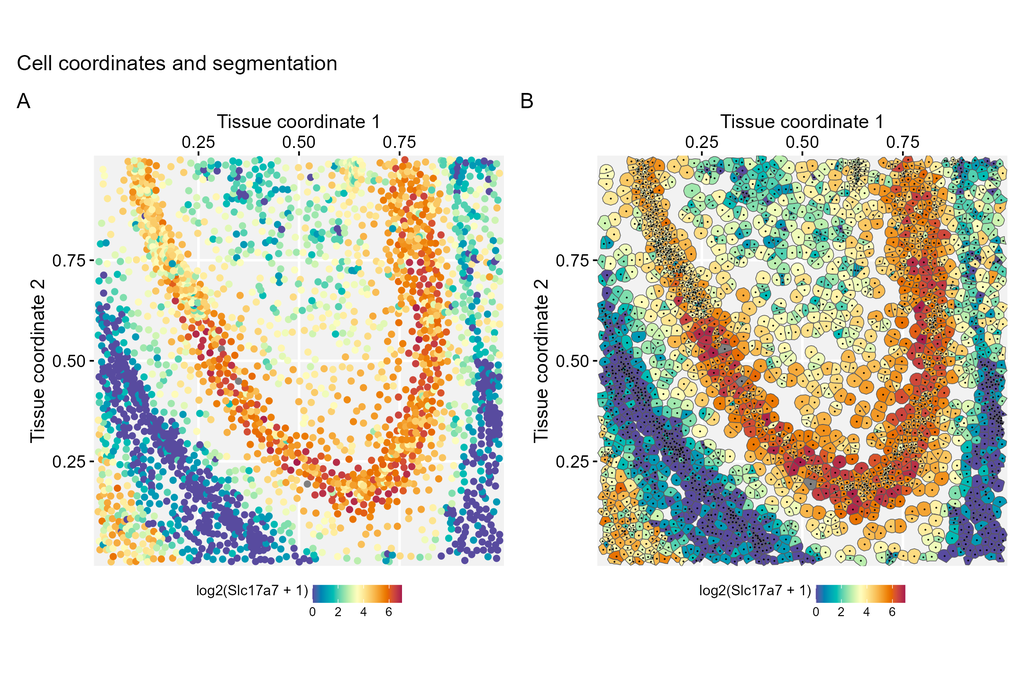

```r
expression_view <- ggplot(gs_crop) +
  geom_nodespace(
    mapping = aes(colour = log2(Slc17a7 + 1)),
    size = 1.5, pch = 19
  ) +
  scale_colour_continuous(palette = cpal, limits = data_range) +
  my_theme

segmentation_view <- ggplot(gs_crop) +
  geom_sf(mapping = aes(geometry = geometry, fill = log2(Slc17a7 + 1))) +
  scale_fill_continuous(palette = cpal, limits = data_range) +
  geom_nodespace(colour = "black", size = 0.2, pch = 19) +
  my_theme

expression_view + segmentation_view +
  plot_annotation(title = "Cell coordinates and segmentation", tag_levels = "A")
```

## 1.2 Inspect polygon types and intersections

The sparse list returned by `st_intersects()` contains the indices of each polygon’s neighbors. Exclude self-intersections explicitly. Using the neighbor list directly also avoids a many-to-many join that repeats cell geometries.

```r
knitr::kable(as.data.frame(table(sf::st_geometry_type(cell_geometry))),
             col.names = c("Geometry", "Cells"))
```

| Geometry | Cells |
| --- | --- |
| GEOMETRY | 0 |
| POINT | 0 |
| LINESTRING | 0 |
| POLYGON | 2652 |
| MULTIPOINT | 0 |
| MULTILINESTRING | 0 |
| MULTIPOLYGON | 2 |
| GEOMETRYCOLLECTION | 0 |
| CIRCULARSTRING | 0 |
| COMPOUNDCURVE | 0 |
| CURVEPOLYGON | 0 |
| MULTICURVE | 0 |
| MULTISURFACE | 0 |
| CURVE | 0 |
| SURFACE | 0 |
| POLYHEDRALSURFACE | 0 |
| TIN | 0 |
| TRIANGLE | 0 |

```r
example_cells <- sf::st_as_sf(gs_crop@nodes[seq_len(9L), ])
intersect_list <- sf::st_intersects(example_cells, remove_self = TRUE)
neighbor_table <- function(neighbor_list) {
  data.frame(
    cell = seq_along(neighbor_list),
    neighbors = vapply(neighbor_list, function(x) paste(x, collapse = ", "), character(1)),
    count = lengths(neighbor_list)
  )
}
knitr::kable(neighbor_table(intersect_list), caption = "Neighbors from polygon intersection")
```

Neighbors from polygon intersection

| cell | neighbors | count |
| --- | --- | --- |
| 1 | 6 | 1 |
| 2 |  | 0 |
| 3 | 5 | 1 |
| 4 |  | 0 |
| 5 | 3, 8 | 2 |
| 6 | 1 | 1 |
| 7 |  | 0 |
| 8 | 5 | 1 |
| 9 |  | 0 |

```r
example_cells$status <- factor(
  ifelse(lengths(intersect_list) > 0L, "Yes", "No"), levels = c("No", "Yes")
)
intersection_plot <- ggplot(data = example_cells) +
  geom_sf(aes(fill = status), show.legend = TRUE) +
  geom_text(aes(x = x, y = y, label = vertex), size = 3) +
  scale_fill_manual(values = c(Yes = "#2b8cbe", No = "grey85"), drop = FALSE) +
  theme_minimal() +
  labs(title = "Intersecting polygons", fill = "Has neighbor?", x = "x", y = "y")
```

## 1.3 Neighbors within a distance

`st_is_within_distance()` compares the minimum distance between polygons with the chosen tolerance. It does not require their original boundaries to overlap. For the visual illustration, buffer each polygon by **half** the tolerance: expanding both polygons by the full tolerance would illustrate twice the intended separation. Curved buffers are approximations; neighbor status always comes from the distance predicate itself.

```r
neighbor_list <- sf::st_is_within_distance(
  example_cells, dist = proximity_threshold, remove_self = TRUE
)
knitr::kable(neighbor_table(neighbor_list), caption = "Neighbors within the selected distance")
```

Neighbors within the selected distance

| cell | neighbors | count |
| --- | --- | --- |
| 1 | 2, 6, 7 | 3 |
| 2 | 1 | 1 |
| 3 | 4, 5, 8 | 3 |
| 4 | 3, 6, 8, 9 | 4 |
| 5 | 3, 8 | 2 |
| 6 | 1, 4, 7, 9 | 4 |
| 7 | 1, 6, 9 | 3 |
| 8 | 3, 4, 5, 9 | 4 |
| 9 | 4, 6, 7, 8 | 4 |

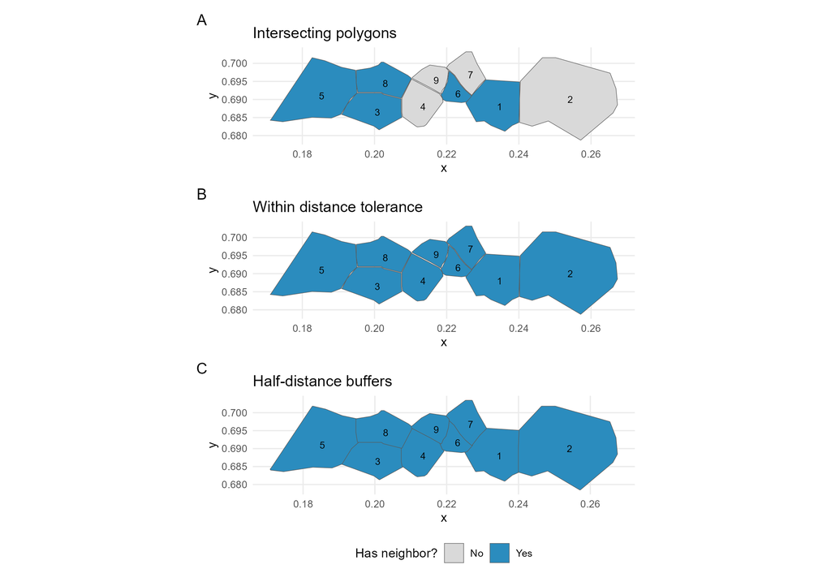

```r
example_cells$status <- factor(
  ifelse(lengths(neighbor_list) > 0L, "Yes", "No"), levels = c("No", "Yes")
)
distance_plot <- ggplot(data = example_cells) +
  geom_sf(aes(fill = status), show.legend = TRUE) +
  geom_text(aes(x = x, y = y, label = vertex), size = 3) +
  scale_fill_manual(values = c(Yes = "#2b8cbe", No = "grey85"), drop = FALSE) +
  theme_minimal() +
  labs(title = "Within distance tolerance", fill = "Has neighbor?", x = "x", y = "y")

buffered_cells <- sf::st_buffer(example_cells, dist = proximity_threshold / 2)
buffer_plot <- ggplot(data = buffered_cells) +
  geom_sf(aes(fill = status), show.legend = TRUE) +
  geom_text(aes(x = x, y = y, label = vertex), size = 3) +
  scale_fill_manual(values = c(Yes = "#2b8cbe", No = "grey85"), drop = FALSE) +
  theme_minimal() +
  labs(title = "Half-distance buffers", fill = "Has neighbor?", x = "x", y = "y")

neighbor_inspection <- intersection_plot + distance_plot + buffer_plot +
  plot_layout(ncol = 1, guides = "collect") + plot_annotation(tag_levels = "A") &
  theme(legend.position = "bottom")
neighbor_inspection
```

```r
save_figure(neighbor_inspection, "InspectingNeighbors.png", width = 10, height = 7)
```

# 2 Polygon geometry

Based on `Vignettes/polygonGeometry.Rmd`.

Measure polygon area, diameter, and perimeter for the full crop. Store these features on the GraphSpace object so the remaining chapters can reuse them.

## 2.1 Calculate spatial metrics once

The diameter is the maximum Euclidean distance between polygon vertices. Remove duplicate closing vertices rather than discarding a vertex by position. `lwgeom::st_perimeter_lwgeom()` supplies the polygon perimeter explicitly.

```r
maxDistPol <- function(polygon) {
  vertices <- unique(sf::st_coordinates(polygon)[, c("X", "Y"), drop = FALSE])
  if (nrow(vertices) < 2L) return(0)
  max(stats::dist(vertices))
}
metric_names <- c("area", "perimeter", "maxDist")
spatial_metrics <- data.frame(
  cell = cell_names,
  area = as.numeric(sf::st_area(cell_geometry)),
  perimeter = as.numeric(lwgeom::st_perimeter_lwgeom(cell_geometry)),
  maxDist = vapply(seq_along(cell_geometry), function(i) {
    maxDistPol(cell_geometry[i])
  }, numeric(1))
)
stopifnot(all(is.finite(as.matrix(spatial_metrics[metric_names]))))
stopifnot(all(as.matrix(spatial_metrics[metric_names]) > 0))
for (metric in metric_names) {
  gs_vertex_attr(gs_crop, metric) <- spatial_metrics[[metric]]
}
meanMaxDist <- mean(spatial_metrics$maxDist)
write.csv(spatial_metrics, file.path(result_dir, "cell-spatial-metrics.csv"), row.names = FALSE)
knitr::kable(summary(spatial_metrics[metric_names]), digits = 6)
```

|  | area | perimeter | maxDist |
| --- | --- | --- | --- |
|  | Min. :5.361e-06 | Min. :0.00988 | Min. :0.004005 |
|  | 1st Qu.:1.406e-04 | 1st Qu.:0.05019 | 1st Qu.:0.019202 |
|  | Median :2.646e-04 | Median :0.06729 | Median :0.025619 |
|  | Mean :3.080e-04 | Mean :0.06677 | Mean :0.025032 |
|  | 3rd Qu.:4.305e-04 | 3rd Qu.:0.08373 | 3rd Qu.:0.031503 |
|  | Max. :1.097e-03 | Max. :0.12281 | Max. :0.042811 |

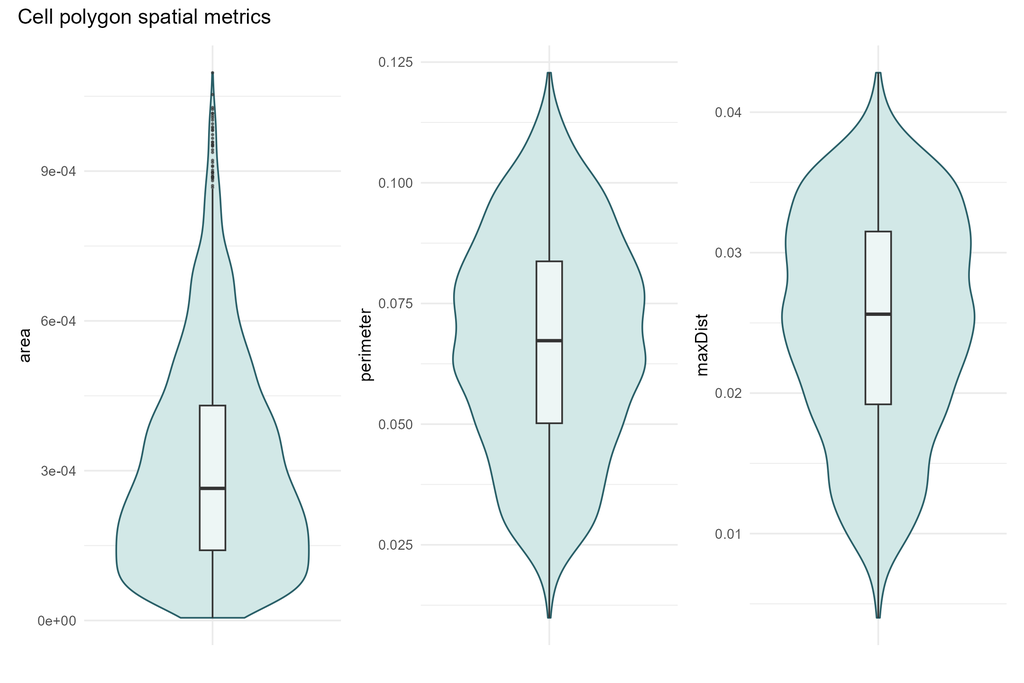

```r
plot_distribution <- function(data, feature, label) {
  ggplot(data, aes(x = "", y = .data[[feature]])) +
    geom_violin(fill = "#d2e8e7", colour = "#285e67") +
    geom_boxplot(width = 0.12, outlier.size = 0.35, alpha = 0.6) +
    theme_minimal() + labs(x = NULL, y = label)
}
metric_plots <- lapply(metric_names, function(metric) {
  plot_distribution(spatial_metrics, metric, metric)
})
spatial_feature_plot <- wrap_plots(metric_plots, nrow = 1) +
  plot_annotation(title = "Cell polygon spatial metrics")
spatial_feature_plot
```

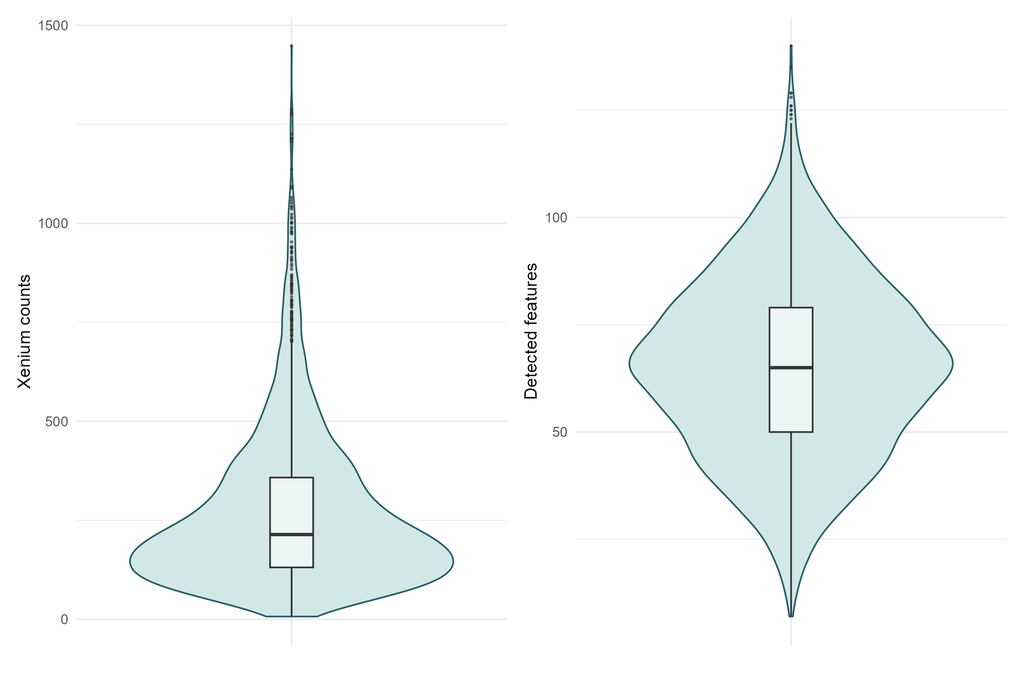

```r
save_figure(spatial_feature_plot, "SpatialFeatures_RawCrop.png", width = 10, height = 4)
plot_distribution(gs_crop@nodes, "nCount_Xenium", "Xenium counts") +
  plot_distribution(gs_crop@nodes, "nFeature_Xenium", "Detected features")
```

## 2.2 Correlate expression with spatial features

To retain the analysis in the vignette, these are correlations with the **raw expression counts** stored in the crop. They are exploratory: library size, cell area, cropping, and spatial dependence can affect the associations. A normalized expression analysis on the full tissue is a useful follow-up.

Align expression rows to cell identifiers explicitly and remove genes with no variation. Calculate both methods through one function. Adjust P-values over all gene-by-feature tests within each method using Benjamini-Hochberg.

```r
expr <- as.matrix(gs_crop@fdata)
expr <- expr[match(cell_names, rownames(expr)), , drop = FALSE]
stopifnot(identical(rownames(expr), cell_names), all(is.finite(expr)))
variable_genes <- apply(expr, 2, stats::sd) > 0
expr <- expr[, variable_genes, drop = FALSE]
meta <- spatial_metrics[metric_names]
stopifnot(ncol(expr) > 0L, all(vapply(meta, stats::sd, numeric(1)) > 0))

correlate_features <- function(method) {
  fit <- psych::corr.test(
    x = expr, y = meta, method = method,
    adjust = "none", use = "pairwise", ci = FALSE
  )
  result <- as.data.frame(as.table(fit$r), responseName = "correlation")
  names(result)[1:2] <- c("gene", "feature")
  result$gene <- as.character(result$gene)
  result$feature <- factor(result$feature, levels = metric_names)
  result$p_value <- as.vector(fit$p)
  result$p_adjusted <- stats::p.adjust(result$p_value, method = "BH")
  result$method <- method
  result
}
correlation_results <- setNames(
  lapply(c("pearson", "spearman"), correlate_features), c("pearson", "spearman")
)
all_correlations <- dplyr::bind_rows(correlation_results)
write.csv(all_correlations, file.path(result_dir, "expression-spatial-correlations.csv"), row.names = FALSE)
knitr::kable(data.frame(
  cells = nrow(expr), variable_genes = ncol(expr), spatial_features = ncol(meta),
  tests_per_method = ncol(expr) * ncol(meta)
), caption = "Correlation analysis dimensions")
```

Correlation analysis dimensions

| cells | variable_genes | spatial_features | tests_per_method |
| --- | --- | --- | --- |
| 2654 | 248 | 3 | 744 |

## 2.3 Plot the significant associations

Use a single rule for both methods: adjusted P-value below 0.01 and absolute correlation of at least 0.3. Symmetric color limits retain negative associations. Each heatmap derives its gene order from its own results. If no associations pass the filters, show that result instead of failing during plotting.

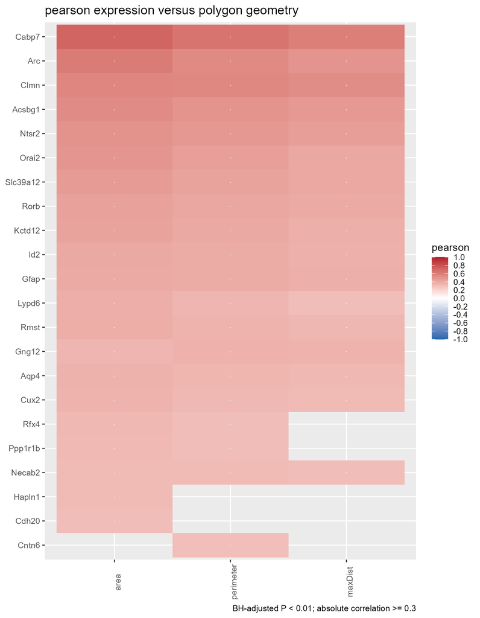

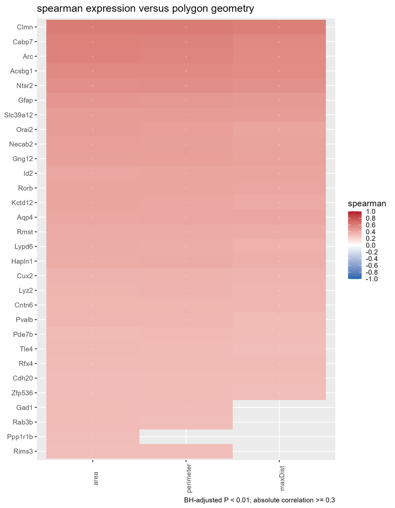

```r
alpha <- 0.01
minimum_correlation <- 0.3
plot_correlations <- function(result, method) {
  selected <- dplyr::filter(
    result, is.finite(correlation), !is.na(p_adjusted),
    p_adjusted < alpha, abs(correlation) >= minimum_correlation
  )
  if (nrow(selected) == 0L) {
    return(ggplot() + annotate("text", x = 0, y = 0, label = "No associations pass the filters") +
             theme_void() + labs(title = paste(method, "correlations")))
  }
  gene_order <- selected |>
    dplyr::group_by(gene) |>
    dplyr::summarise(strength = max(abs(correlation)), .groups = "drop") |>
    dplyr::arrange(strength, gene) |>
    dplyr::pull(gene)
  microbiome::heat(
    as.data.frame(selected), "feature", "gene", fill = "correlation",
    star = "p_adjusted", p.adj.threshold = alpha,
    association.threshold = minimum_correlation, filter.significant = FALSE,
    order.rows = FALSE, order.cols = FALSE,
    colours = c("#2166ac", "white", "#b2182b"), limits = c(-1, 1),
    legend.text = method
  ) + scale_x_discrete(limits = metric_names) + scale_y_discrete(limits = gene_order) +
    labs(title = paste(method, "expression versus polygon geometry"),
         caption = "BH-adjusted P < 0.01; absolute correlation >= 0.3", x = NULL, y = NULL)
}
for (method in names(correlation_results)) {
  heatmap <- plot_correlations(correlation_results[[method]], method)
  print(heatmap)
  save_figure(heatmap, paste0(method, "-spatial-correlations.png"), width = 7, height = 9)
}
```

```r
significant_correlations <- dplyr::filter(
  all_correlations, p_adjusted < alpha, abs(correlation) >= minimum_correlation
)
write.csv(significant_correlations, file.path(result_dir, "significant-correlations.csv"), row.names = FALSE)
knitr::kable(as.data.frame(table(significant_correlations$method)),
             col.names = c("Method", "Significant gene-feature pairs"))
```

| Method | Significant gene-feature pairs |
| --- | --- |
| pearson | 58 |
| spearman | 85 |

## 2.4 Polygon centers

A mathematical centroid can lie outside a concave polygon. `st_point_on_surface()` supplies an interior point. The existing GraphSpace coordinates are retained throughout the network comparisons.

```r
example_geometry <- sf::st_geometry(example_cells)
center_comparison <- data.frame(
  cell = example_cells$vertex,
  centroid_inside = diag(sf::st_within(
    sf::st_centroid(example_geometry), example_geometry, sparse = FALSE
  )),
  surface_point_inside = diag(sf::st_within(
    sf::st_point_on_surface(example_geometry), example_geometry, sparse = FALSE
  ))
)
knitr::kable(center_comparison)
```

| cell | centroid_inside | surface_point_inside |
| --- | --- | --- |
| 1 | TRUE | TRUE |
| 2 | TRUE | TRUE |
| 3 | TRUE | TRUE |
| 4 | TRUE | TRUE |
| 5 | TRUE | TRUE |
| 6 | TRUE | TRUE |
| 7 | TRUE | TRUE |
| 8 | TRUE | TRUE |
| 9 | TRUE | TRUE |

# 3 Delaunay and proximity networks

Based on `Vignettes/DelaunayNet.Rmd`.

Delaunay triangulation uses the cell coordinates. The proximity graph uses distances between segmentation polygons. Both graphs retain the same cell identifiers, so their edges can be compared as labeled cell pairs.

## 3.1 Build the Delaunay graph

```r
xy <- as.matrix(gs_crop@nodes[, c("x", "y")])
stopifnot(all(is.finite(xy)), !anyDuplicated(as.data.frame(xy)))
triangulation <- deldir::deldir(xy[, 1], xy[, 2], suppressMsge = TRUE)
triangulation_indices <- triangulation$delsgs[, c("ind1", "ind2")]
delaunay_edges <- data.frame(
  from = cell_names[triangulation_indices$ind1],
  to = cell_names[triangulation_indices$ind2]
)
gs_crop_dnay <- gs_add_edges(gs_crop, delaunay_edges)
gs_edge_attr(gs_crop_dnay, "arrowType") <- 0
stopifnot(
  igraph::ecount(gs_crop_dnay@graph) == nrow(delaunay_edges),
  igraph::is_simple(gs_crop_dnay@graph)
)
knitr::kable(utils::head(delaunay_edges), caption = "Delaunay edges mapped to cell names")
```

Delaunay edges mapped to cell names

| from | to |
| --- | --- |
| 18745 | 18734 |
| 18981 | 18734 |
| 18981 | 18745 |
| 18982 | 18981 |
| 18983 | 18745 |
| 18983 | 18981 |

## 3.2 Prepare reusable proximity candidates

Find candidate pairs once at the largest distance used in the book. Compute their exact polygon distances and retain one row per undirected pair. Any smaller threshold can then filter this table without repeating a full spatial query. The helper checks its distance range and cell identifiers before adding edges.

```r
maximum_distance <- max(distance_grid)
candidate_neighbors <- sf::st_is_within_distance(
  cell_geometry, dist = maximum_distance, remove_self = TRUE
)
candidate_indices <- data.frame(
  from_index = rep(seq_along(candidate_neighbors), lengths(candidate_neighbors)),
  to_index = unlist(candidate_neighbors, use.names = FALSE)
)
candidate_indices <- candidate_indices[
  candidate_indices$from_index < candidate_indices$to_index, , drop = FALSE
]
proximity_candidates <- data.frame(
  from = cell_names[candidate_indices$from_index],
  to = cell_names[candidate_indices$to_index],
  distance = as.numeric(sf::st_distance(
    cell_geometry[candidate_indices$from_index],
    cell_geometry[candidate_indices$to_index], by_element = TRUE
  ))
)
stopifnot(
  !anyDuplicated(proximity_candidates[c("from", "to")]),
  all(is.finite(proximity_candidates$distance)),
  all(proximity_candidates$distance <= maximum_distance + 1e-12)
)
gs_neighbors <- function(gs, dist) {
  stopifnot(length(dist) == 1L, is.finite(dist), dist >= 0, dist <= maximum_distance)
  stopifnot(identical(as.character(gs_vertex_attr(gs, "name")), cell_names))
  stopifnot(igraph::ecount(gs@graph) == 0L)
  edges <- proximity_candidates[
    proximity_candidates$distance <= dist, c("from", "to"), drop = FALSE
  ]
  if (nrow(edges) == 0L) return(gs)
  result <- gs_add_edges(gs, edges)
  gs_edge_attr(result, "arrowType") <- 0
  stopifnot(igraph::is_simple(result@graph), igraph::ecount(result@graph) == nrow(edges))
  result
}
gs_crop_prox <- gs_neighbors(gs_crop, dist = proximity_threshold)
write.csv(proximity_candidates, file.path(result_dir, "proximity-candidate-distances.csv"), row.names = FALSE)
```

## 3.3 Compare the graph views

The polygon diameters calculated in Chapter 2 are already attached to both graph objects. Plot segmentation, cell coordinates, and the two edge sets.

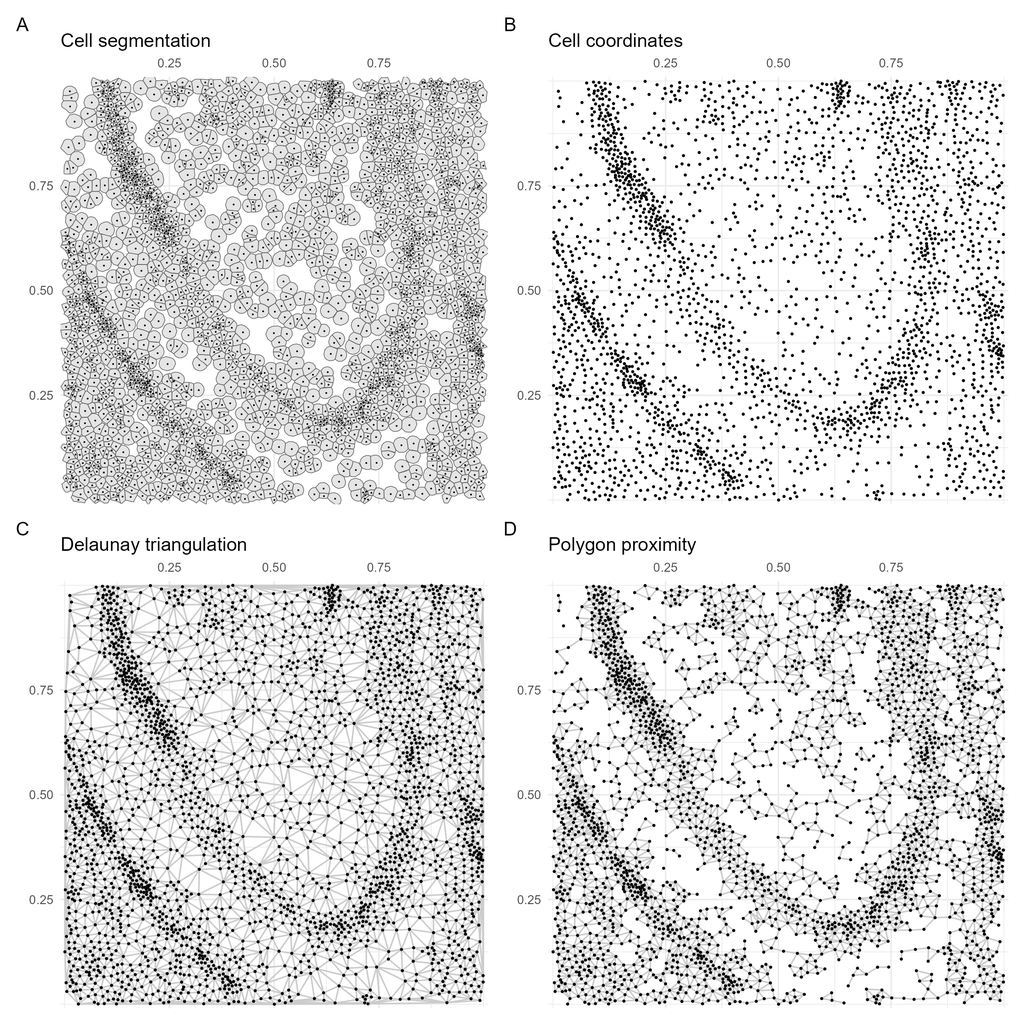

```r
segmentation_plot <- ggplot(gs_crop) +
  geom_sf(mapping = aes(geometry = geometry)) +
  geom_nodespace(colour = "black", size = 0.2, pch = 19) +
  theme_gspace_coords(theme = "th3", is_norm = TRUE) +
  theme_minimal() +
  labs(title = "Cell segmentation", x = NULL, y = NULL)

coordinate_plot <- ggplot(gs_crop_dnay) +
  geom_nodespace(colour = "black", size = 0.5, pch = 19) +
  theme_gspace_coords(theme = "th3", is_norm = TRUE) +
  theme_minimal() +
  labs(title = "Cell coordinates", x = NULL, y = NULL)

delaunay_plot <- ggplot(gs_crop_dnay) +
  geom_edgespace() +
  geom_nodespace(colour = "black", size = 0.5, pch = 19) +
  theme_gspace_coords(theme = "th3", is_norm = TRUE) +
  theme_minimal() +
  labs(title = "Delaunay triangulation", x = NULL, y = NULL)

proximity_plot <- ggplot(gs_crop_prox) +
  geom_edgespace() +
  geom_nodespace(colour = "black", size = 0.5, pch = 19) +
  theme_gspace_coords(theme = "th3", is_norm = TRUE) +
  theme_minimal() +
  labs(title = "Polygon proximity", x = NULL, y = NULL)

delaunay_figure <- segmentation_plot + coordinate_plot + delaunay_plot +
  plot_layout(nrow = 1) + plot_annotation(tag_levels = "A")
network_comparison <- segmentation_plot + coordinate_plot + delaunay_plot + proximity_plot +
  plot_layout(ncol = 2) + plot_annotation(tag_levels = "A")
network_comparison
```

```r
save_figure(delaunay_figure, "GraphSpace_Delaunay.png", width = 12, height = 4)
save_figure(network_comparison, "GraphSpace_Delaunay_Proximity.png", width = 10, height = 10)
```

## 3.4 Compare labeled edge sets

Canonical edge keys preserve cell identity when checking shared and unique pairs. The subset result and edge counts are calculated from this render’s data rather than copied from a previous run.

```r
edge_keys <- function(graph) {
  edges <- igraph::as_data_frame(graph, what = "edges")
  paste(pmin(edges$from, edges$to), pmax(edges$from, edges$to), sep = "|")
}
delaunay_keys <- edge_keys(gs_crop_dnay@graph)
proximity_keys <- edge_keys(gs_crop_prox@graph)
edge_comparison <- data.frame(
  metric = c("Delaunay edges", "Proximity edges", "Shared edges", "Delaunay only", "Proximity only"),
  value = c(length(delaunay_keys), length(proximity_keys),
            length(intersect(delaunay_keys, proximity_keys)),
            length(setdiff(delaunay_keys, proximity_keys)),
            length(setdiff(proximity_keys, delaunay_keys)))
)
knitr::kable(edge_comparison)
```

| metric | value |
| --- | --- |
| Delaunay edges | 7936 |
| Proximity edges | 6581 |
| Shared edges | 6106 |
| Delaunay only | 1830 |
| Proximity only | 475 |

```r
cat("Every proximity edge is also a Delaunay edge:", all(proximity_keys %in% delaunay_keys))
```

```
Every proximity edge is also a Delaunay edge: FALSE
```

```r
write.csv(edge_comparison, file.path(result_dir, "network-edge-comparison.csv"), row.names = FALSE)
```

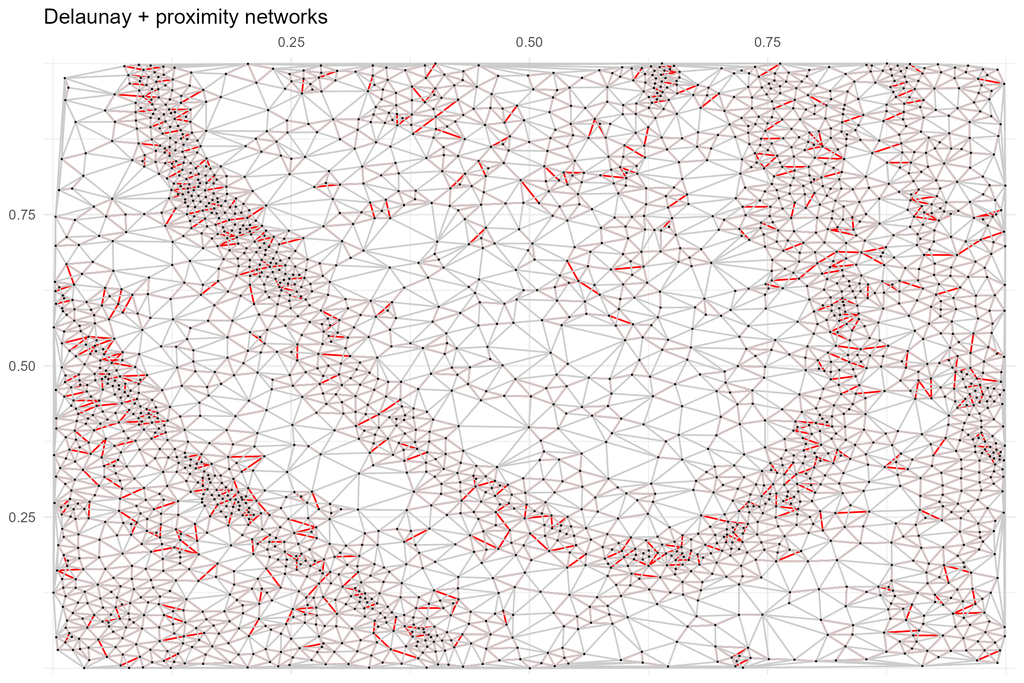

```r
network_overlay <- ggplot() +
  geom_edgespace(data = gs_crop_prox, colour = "red") +
  geom_edgespace(data = gs_crop_dnay, alpha = 1) +
  geom_nodespace(data = gs_crop_dnay, colour = "black", size = 0.2, pch = 19) +
  scale_colour_continuous(palette = cpal, limits = data_range) +
  theme_gspace_coords(theme = "th3", is_norm = TRUE) +
  theme_minimal() +
  labs(title = "Delaunay + proximity networks", x = NULL, y = NULL)
network_overlay
```

```r
save_figure(network_overlay, "GraphSpace_Network_Overlay.png", width = 8, height = 7)
```

# 4 Setting the proximity distance

Based on `Vignettes/SettingDist_proximityNetwork.Rmd`.

Explore thresholds from 0 to 0.002 in increments of 0.0001. The candidate distance table from Chapter 3 makes this sweep inexpensive. Store plots in a list so that each entry remains a complete ggplot object.

## 4.1 Build the distance sweep

```r
edges_by_dist <- data.frame(dist = distance_grid, edges = integer(length(distance_grid)))
sweep_plots <- vector("list", length(distance_grid) + 1L)
sweep_plots[[1L]] <- ggplot(gs_crop) +
  geom_edgespace(colour = "red") +
  geom_nodespace(colour = "black", size = 0.2, pch = 19) +
  scale_colour_continuous(palette = cpal, limits = data_range) +
  theme_gspace_coords(theme = "th3", is_norm = TRUE) +
  theme_minimal() +
  labs(title = "Cell proximity: no edges", x = NULL, y = NULL)

sweep_started <- Sys.time()
for (i in seq_along(distance_grid)) {
  gs_prox <- gs_neighbors(gs_crop, dist = distance_grid[i])
  edges_by_dist$edges[i] <- igraph::ecount(gs_prox@graph)
  sweep_plots[[i + 1L]] <- ggplot(gs_prox) +
    geom_edgespace(colour = "red") +
    geom_nodespace(colour = "black", size = 0.2, pch = 19) +
    scale_colour_continuous(palette = cpal, limits = data_range) +
    theme_gspace_coords(theme = "th3", is_norm = TRUE) +
    theme_minimal() +
    labs(title = sprintf("Cell proximity: distance = %.4f", distance_grid[i]),
         x = NULL, y = NULL)
}
sweep_seconds <- as.numeric(difftime(Sys.time(), sweep_started, units = "secs"))
stopifnot(all(diff(edges_by_dist$edges) >= 0L))
knitr::kable(edges_by_dist, digits = 4, caption = "Edges at each polygon distance threshold")
```

Edges at each polygon distance threshold

| dist | edges |
| --- | --- |
| 0.0000 | 1356 |
| 0.0001 | 3803 |
| 0.0002 | 5952 |
| 0.0003 | 6466 |
| 0.0004 | 6521 |
| 0.0005 | 6581 |
| 0.0006 | 6601 |
| 0.0007 | 6655 |
| 0.0008 | 6680 |
| 0.0009 | 6717 |
| 0.0010 | 6737 |
| 0.0011 | 6790 |
| 0.0012 | 6819 |
| 0.0013 | 6861 |
| 0.0014 | 6893 |
| 0.0015 | 6946 |
| 0.0016 | 6972 |
| 0.0017 | 7017 |
| 0.0018 | 7047 |
| 0.0019 | 7093 |
| 0.0020 | 7121 |

```r
cat(sprintf("Graph construction and plot preparation: %.2f seconds", sweep_seconds))
```

```
Graph construction and plot preparation: 192.92 seconds
```

```r
write.csv(edges_by_dist, file.path(result_dir, "edges-by-distance.csv"), row.names = FALSE)
```

## 4.2 Save frames and render the animation

The frame directory is created in the shared setup. PNG dimensions match the GIF dimensions. The animation includes all tested thresholds, starting at zero.

```r
frame_files <- vapply(seq_along(sweep_plots), function(i) {
  path <- file.path(frame_dir, sprintf("frame_%03d.png", i))
  ggplot2::ggsave(path, plot = sweep_plots[[i]], width = 6, height = 6,
                  units = "in", dpi = 120, bg = "white")
  path
}, character(1))
gif_file <- file.path(figure_dir, "CellProx_Dist.gif")
gifski::gifski(
  png_files = frame_files[-1L], gif_file = gif_file,
  width = 720, height = 720, delay = 0.2, progress = FALSE
)
```

```
[1] "D:\\SpatialTranscriptomic_Doc\\R_PROJECTS\\Xenium_CellCom\\Book\\figures\\CellProx_Dist.gif"
```

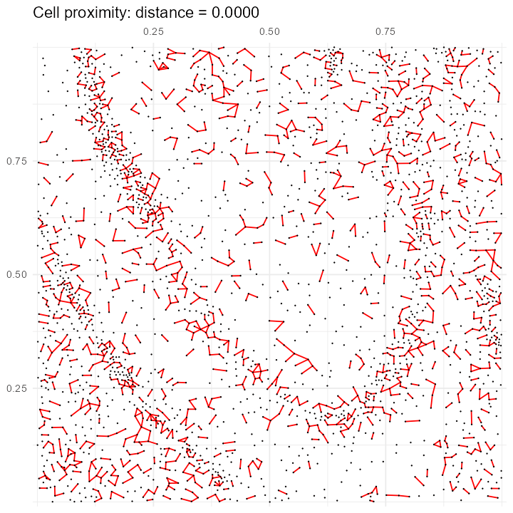

```r
knitr::include_graphics(gif_file)
```

## 4.3 Relate distance to network size and cell diameter

Reuse the mean diameter from Chapter 2. The diameter ratio expresses the threshold relative to polygon size in the same normalized coordinate system.

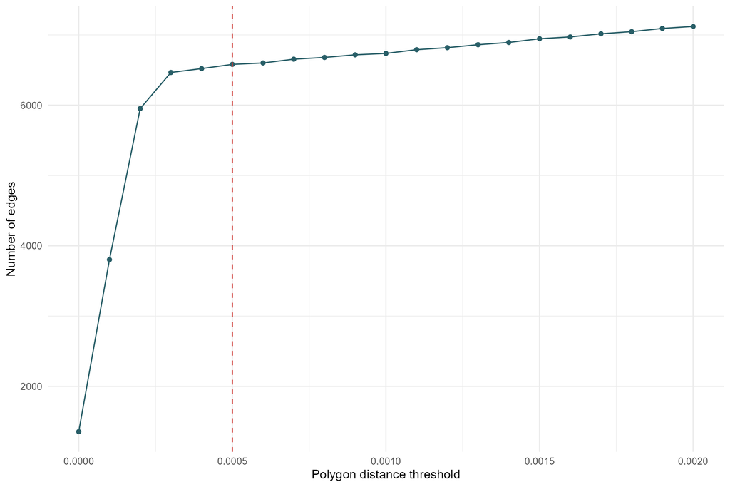

```r
edge_count_plot <- ggplot(edges_by_dist, aes(x = dist, y = edges)) +
  geom_line(colour = "#285e67") + geom_point(colour = "#285e67", size = 1.5) +
  geom_vline(xintercept = proximity_threshold, linetype = 2, colour = "#cf3b36") +
  theme_minimal() + labs(x = "Polygon distance threshold", y = "Number of edges")
edge_count_plot
```

```r
save_figure(edge_count_plot, "Proximity_Distance_NumberEdges.png", width = 8, height = 4.5)
knitr::kable(data.frame(
  selected_distance = proximity_threshold,
  mean_polygon_diameter = meanMaxDist,
  distance_to_diameter_ratio = proximity_threshold / meanMaxDist
), digits = 6)
```

| selected_distance | mean_polygon_diameter | distance_to_diameter_ratio |
| --- | --- | --- |
| 5e-04 | 0.025032 | 0.019975 |

# 5 Visualizing direct neighbors

Based on `Vignettes/Visualizing_DirectNeighbors.Rmd`.

Reuse the proximity graph built in Chapter 3. First compare an edge-only view with edges over the segmentation polygons; then focus on a smaller region and vary the edge and node rendering. Finally, replace the visual implication of a centroid-to-centroid connection with a representative point in the buffered contact region between each neighboring cell pair.

## 5.1 View the neighbor network

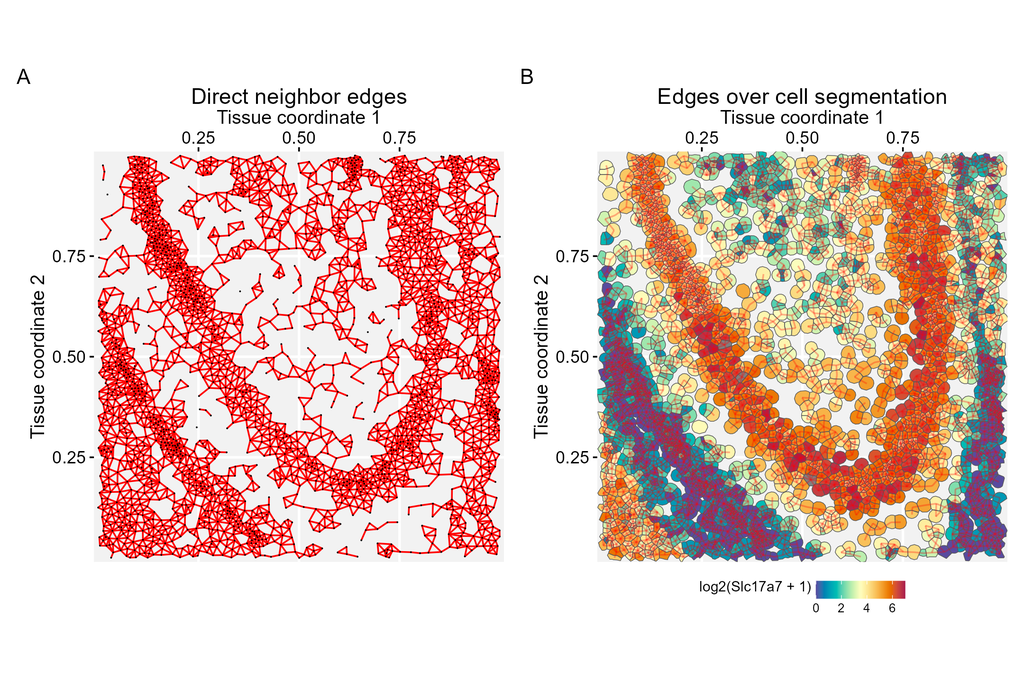

```r
direct_edges_plot <- ggplot(gs_crop_prox) +
  geom_edgespace(colour = "red") +
  geom_nodespace(colour = "black", size = 0.2, pch = 19) +
  scale_colour_continuous(palette = cpal, limits = data_range) +
  my_theme +
  labs(title = "Direct neighbor edges")

direct_segmentation_plot <- ggplot(gs_crop_prox) +
  geom_sf(mapping = aes(geometry = geometry, fill = log2(Slc17a7 + 1))) +
  scale_fill_continuous(palette = cpal, limits = data_range) +
  geom_edgespace(colour = "red", alpha = 0.3) +
  my_theme +
  labs(title = "Edges over cell segmentation")

direct_neighbor_views <- direct_edges_plot + direct_segmentation_plot +
  plot_annotation(tag_levels = "A")
direct_neighbor_views
```

```r
save_figure(direct_neighbor_views, "DirectNeighbors_Overview.png", width = 11, height = 5)
```

## 5.2 Crop and normalize the close-up

```r
gs_neig2 <- cropGraphSpace(
  gs_crop_prox, xmin = 0.45, xmax = 0.6, ymin = 0.2, ymax = 0.35
)
```

```
Cropping graph space to x in [0.45, 0.6], y in [0.2, 0.35]...
```

```r
stopifnot(nrow(gs_neig2@nodes) > 0L)
gs_neig2 <- normalizeGraphSpace(gs_neig2, mar = 0, norm.geometry = TRUE)
```

```
Normalizing node coordinates to graph space...
Normalizing 'geometry' coordinates...
```

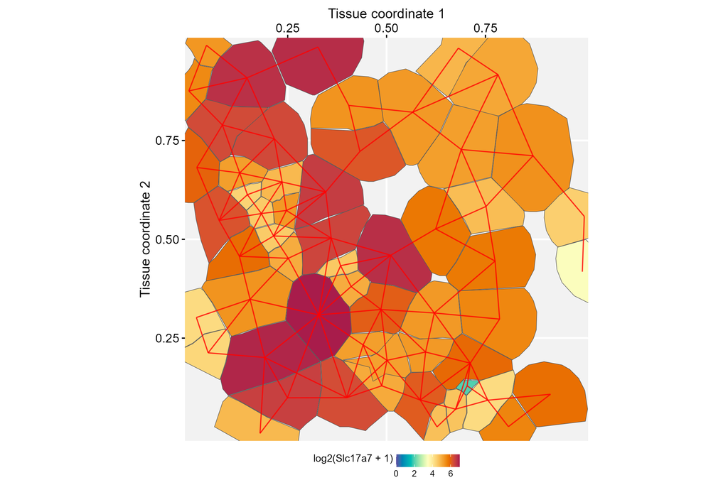

```r
closeup_edges <- ggplot(gs_neig2) +
  geom_sf(mapping = aes(geometry = geometry, fill = log2(Slc17a7 + 1))) +
  scale_fill_continuous(palette = cpal, limits = data_range) +
  geom_edgespace(colour = "red", alpha = 0.8) +
  my_theme
closeup_edges
```

```r
save_figure(closeup_edges, "DirectNeighbors_Edges1.png", width = 7, height = 4)
```

## 5.3 Compare edge rendering

Follow the vignette’s explicit plotting calls for the arrow type and transparent-node experiment. `geom_edgespace()` uses the graph’s edge attributes, while `geom_nodespace()` supplies the node layer in the final view.

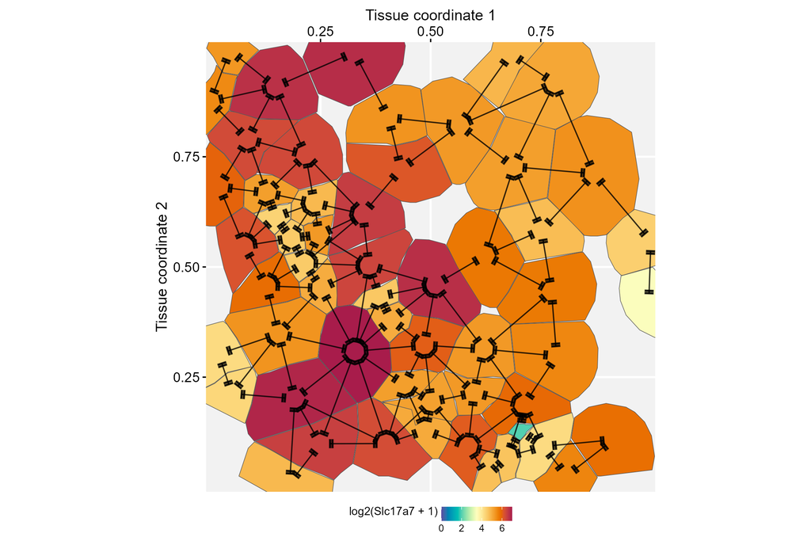

```r
gs_edge_attr(gs_neig2, "arrowType") <- "13|-|13"

closeup_arrow <- ggplot(gs_neig2) +
  geom_sf(mapping = aes(geometry = geometry, fill = log2(Slc17a7 + 1))) +
  scale_fill_continuous(palette = cpal, limits = data_range) +
  geom_edgespace(colour = "black", alpha = 0.8) +
  my_theme
closeup_arrow
```

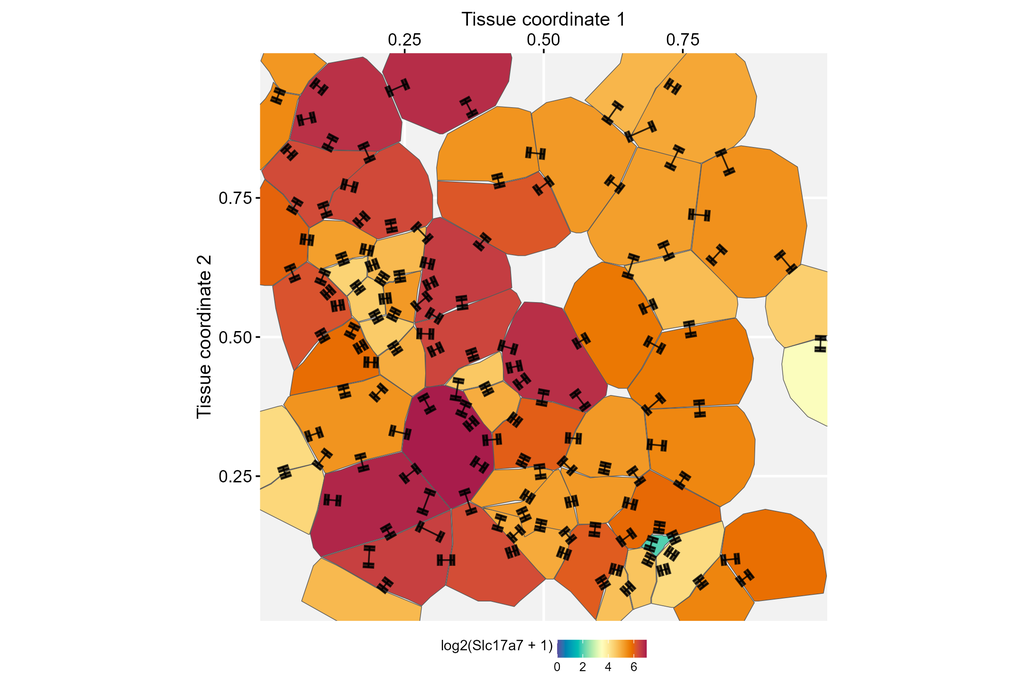

```r
save_figure(closeup_arrow, "DirectNeighbors_Edges2.png", width = 7, height = 4)

closeup_transparent <- ggplot(gs_neig2) +
  geom_sf(mapping = aes(geometry = geometry, fill = log2(Slc17a7 + 1))) +
  scale_fill_continuous(palette = cpal, limits = data_range) +
  geom_nodespace(colour = "black", size = 15, pch = 19, alpha = 0) +
  geom_edgespace(colour = "black", alpha = 0.8) +
  my_theme
closeup_transparent
```

```r
save_figure(closeup_transparent, "DirectNeighbors_Edges3.png", width = 7, height = 4)

knitr::kable(data.frame(
  closeup_cells = nrow(gs_neig2@nodes), closeup_edges = igraph::ecount(gs_neig2@graph)
))
```

| closeup_cells | closeup_edges |
| --- | --- |
| 56 | 124 |

## 5.4 Why centroid-to-centroid edges can be misleading

However, this visualization is not ideal for representing physical contact between neighboring cells because the edges generated by `geom_edgespace()` connect the centroids of adjacent cells.

Cell boundaries can be irregular, and neighboring cells can differ substantially in size. Moreover, some cells share only a small portion of their boundaries (cell membranes). Consequently, edges connecting cell centroids may extend beyond the boundaries of the corresponding cell pair or pass through regions not occupied by either cell.

## 5.5 Rescale the proximity threshold

To identify a point within the contact region between two neighboring cells, first buffer both cell polygons by the `proximity_threshold` distance and compute their intersection using `sf::st_intersection()`. Then use `sf::st_point_on_surface()` to obtain a representative point within the resulting intersection geometry.

When the cropped `GraphSpace` object is re-normalized using `normalizeGraphSpace()`, the `proximity_threshold` parameter must also be rescaled. The rescaling factor can be calculated by comparing the area of each cropped cell polygon before and after normalization.

Let $A_i^{\mathrm{before}}$ and $A_i^{\mathrm{after}}$ denote the areas of polygon $i$ before and after normalization. If normalization applies an isotropic linear scale factor $s_i$, lengths are multiplied by $s_i$, while areas are multiplied by $s_i^2$:

$$A_i^{\mathrm{after}} = s_i^2 A_i^{\mathrm{before}}.$$

Therefore, the linear scale factor obtained from the area ratio is

$$s_i = \sqrt{\frac{A_i^{\mathrm{after}}}{A_i^{\mathrm{before}}}}.$$

The script uses the median scale factor across polygons. Thus, the threshold in normalized coordinates is

$$d_{\mathrm{normalized}}
= d_{\mathrm{original}}
\operatorname{median}_i\!\left(
\sqrt{\frac{A_i^{\mathrm{after}}}{A_i^{\mathrm{before}}}}
\right).$$

```r
gs_contact <- cropGraphSpace(
  gs_crop_prox, xmin = 0.45, xmax = 0.6, ymin = 0.2, ymax = 0.35
)
```

```
Cropping graph space to x in [0.45, 0.6], y in [0.2, 0.35]...
```

```r
before <- sf::st_as_sf(gs_contact[["nodes"]])
gs_contact <- normalizeGraphSpace(gs_contact, mar = 0, norm.geometry = TRUE)
```

```
Normalizing node coordinates to graph space...
Normalizing 'geometry' coordinates...
```

```r
after <- sf::st_as_sf(gs_contact[["nodes"]])
before <- before[match(after$name, before$name), ]

area_ratio <- as.numeric(sf::st_area(after) / sf::st_area(before))
proximity_threshold_zoom <- proximity_threshold * median(sqrt(area_ratio))
threshold_scale <- proximity_threshold_zoom / proximity_threshold
stopifnot(
  all(is.finite(area_ratio)), all(area_ratio > 0),
  is.finite(proximity_threshold_zoom), proximity_threshold_zoom > 0
)
knitr::kable(data.frame(
  original_threshold = proximity_threshold,
  scaling_factor = threshold_scale,
  normalized_threshold = proximity_threshold_zoom
), digits = 7, caption = "Rescaling the proximity threshold")
```

Rescaling the proximity threshold

| original_threshold | scaling_factor | normalized_threshold |
| --- | --- | --- |
| 5e-04 | 6.920188 | 0.0034601 |

```r
rm(before, after)
```

For this crop, the threshold is multiplied by a factor of approximately 6.92 (about 7), changing it from 0.0005 to approximately 0.00346 in the normalized coordinate system.

## 5.6 Calculate and visualize contact points

For every neighbor edge, select its two cell polygons, buffer both polygons using the rescaled threshold, and intersect the corresponding buffered geometries element by element. `st_point_on_surface()` then returns a representative point within each intersection geometry, which is stored as the `intersect_point` edge attribute.

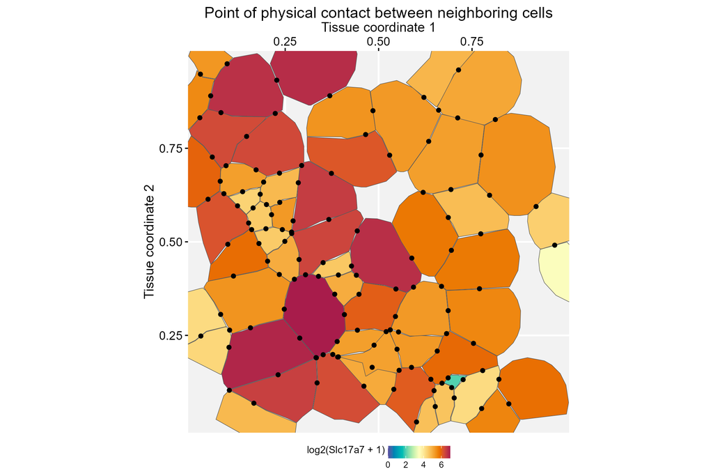

```r
gs_edge_attr(gs_contact, "intersect_point") <-
  st_intersection(
    gs_contact[["nodes"]][gs_contact[["edges"]]$name1, ]$geometry %>%
      sf::st_buffer(dist = proximity_threshold_zoom),
    gs_contact[["nodes"]][gs_contact[["edges"]]$name2, ]$geometry %>%
      sf::st_buffer(dist = proximity_threshold_zoom),
    by_element = TRUE
  ) %>%
  st_point_on_surface()

contact_point_plot <- ggplot(gs_contact) +
  geom_sf(mapping = aes(geometry = geometry, fill = log2(Slc17a7 + 1))) +
  scale_fill_continuous(palette = cpal, limits = data_range) +
  geom_sf(
    data = gs_contact[["edges"]]$intersect_point,
    colour = "black", alpha = 1
  ) +
  my_theme +
  labs(title = "Point of physical contact between neighboring cells")
contact_point_plot
```

```r
save_figure(
  contact_point_plot, "DirectNeighbors_Edges_PointOfContact.png",
  width = 7, height = 4
)
```

## 5.7 Reproducibility and output checks

The output checks verify the main analysis tables, generated figures, frame files, animation, graph consistency, and threshold sweep. Package versions and session information are saved alongside the result tables.

```r
stopifnot(
  nrow(spatial_metrics) == length(cell_names),
  identical(as.character(gs_vertex_attr(gs_crop_dnay, "name")), cell_names),
  identical(as.character(gs_vertex_attr(gs_crop_prox, "name")), cell_names),
  igraph::is_simple(gs_crop_dnay@graph), igraph::is_simple(gs_crop_prox@graph),
  all(diff(edges_by_dist$edges) >= 0L),
  all(file.exists(frame_files)), file.exists(gif_file), file.info(gif_file)$size > 0,
  length(gs_contact[["edges"]]$intersect_point) == igraph::ecount(gs_contact@graph),
  file.exists(file.path(figure_dir, "DirectNeighbors_Edges_PointOfContact.png"))
)
capture.output(sessionInfo(), file = file.path(result_dir, "session-info.txt"))
write.csv(data.frame(
  dataset = basename(data_file), md5 = unname(tools::md5sum(data_file)),
  selected_distance = proximity_threshold, maximum_distance = maximum_distance,
  mean_polygon_diameter = meanMaxDist
), file.path(result_dir, "render-inputs.csv"), row.names = FALSE)
knitr::kable(data.frame(
  output = c("Figures and animation", "Animation frames", "Analysis tables and session information"),
  directory = c("Book/figures", "Book/frames", "Book/results")
))
```

| output | directory |
| --- | --- |
| Figures and animation | Book/figures |
| Animation frames | Book/frames |
| Analysis tables and session information | Book/results |

[session information not shown]

## 5.8 References and source vignettes

The five source vignettes are `InspectingNeighbors.Rmd`, `polygonGeometry.Rmd`, `DelaunayNet.Rmd`, `SettingDist_proximityNetwork.Rmd`, and `Visualizing_DirectNeighbors.Rmd`, all in the project’s `Vignettes` directory.

For the spatial graph and geometry APIs, see the [RGraphSpace nested geometries tutorial](https://sysbiolab.github.io/RGraphSpace/articles/nested-geometries.html), [GraphSpace accessors and transformations](https://sysbiolab.github.io/RGraphSpace/articles/graphspace-accessors.html), and the [sf geometric predicate reference](https://r-spatial.github.io/sf/reference/geos_binary_pred.html). The HTML is produced with [Quarto](https://quarto.org/docs/output-formats/html-basics.html).